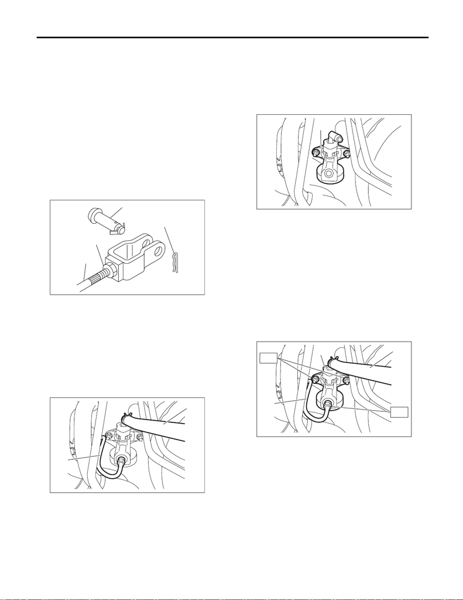

CL-24

Master Cylinder

CLUTCH SYSTEM

6. Master Cylinder

A: REMOVAL

1) Disconnect the ground cable from battery. <Ref.

to NT-5, BATTERY, NOTE, Note.>

NOTE:

For models other than STI model, disconnect the

ground terminal from battery sensor.

2) Thoroughly drain the clutch fluid from the reser-

voir tank.

3) Remove the instrument panel lower cover. <Ref.

to EI-61, REMOVAL, Instrument Panel Lower Cov-

er.>

4) Remove the snap pin and clevis pin, and then

separate the push rod of the master cylinder from

clutch pedal.

5) Remove the intercooler. <Ref. to IN(STI)-13,

REMOVAL, Intercooler.> <Ref. to IN(w/o STI)-38,

REMOVAL, Intercooler.>

6) Disconnect the clutch pipe and reservoir hose

from the master cylinder.

7) Remove the clutch bracket from the bulkhead.

8) Remove the master cylinder.

CAUTION:

paint surface; wash it off with water and wipe

clean quickly if spilled.

B: INSTALLATION

1) Attach the clutch bracket to the bulkhead.

Tightening torque:

25 N·m (2.5 kgf-m, 18.4 ft-lb)

2) Install the master cylinder to the vehicle body,

and connect the clutch pipe and reservoir hose to

the master cylinder.

Tightening torque:

T1: 15 N·m (1.5 kgf-m, 11.1 ft-lb)

T2: 18 N·m (1.8 kgf-m, 13.3 ft-lb)

(A) Clevis pin

(B) Snap pin

(C) Push rod

(D) Lock nut

(A) Reservoir hose

(B) Clutch pipe

CL-00042

(A)

(B)

(C)

(D)

CL-01003

(B)

(A)

(A) Master cylinder

(A) Reservoir hose

(B) Clutch pipe

(C) Master cylinder

CL-01004

(A)

CL-01005

(B)

(A)

(C)

T1

T2

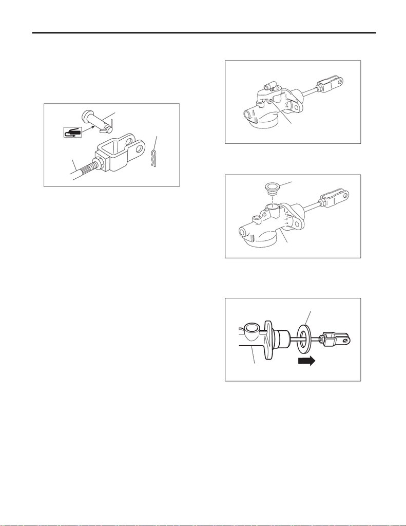

CL-25

Master Cylinder

CLUTCH SYSTEM

3) Connect the push rod of the master cylinder to

the clutch pedal, and install the clevis pin and snap

pin.

CAUTION:

Always use a new clevis pin.

NOTE:

Apply grease to the clevis pin.

4) Refill the reservoir tank with recommended

clutch fluid.

5) After bleeding air from the clutch system, ensure

that the clutch operates properly.

<Ref. to CL-29, Clutch Fluid Air Bleeding.>

6) Install the intercooler. <Ref. to IN(STI)-14, IN-

STALLATION, Intercooler.> <Ref. to IN(w/o STI)-

41, INSTALLATION, Intercooler.>

7) Connect the battery ground terminal. <Ref. to

NT-5, BATTERY, NOTE, Note.>

NOTE:

For models other than STI model, connect the

ground terminal to battery sensor.

C: DISASSEMBLY

1) Remove the straight pin and nipple.

2) Remove the oil seal.

3) Move the seat towards the rear.

4) Remove the piston stop ring.

CAUTION:

When removing the piston stop ring, be careful

to prevent the rod, washer, piston and return

spring from popping out.

(A) Clevis pin

(B) Snap pin

(C) Push rod

CL-00045

(A)

(B)

(C)

(A) Straight pin

(A) Oil seal

(B) Master cylinder

(A) Seat

(B) Master cylinder

CL-01006

(A)

CL-01007

(A)

(B)

CL-00513

(A)

(B)

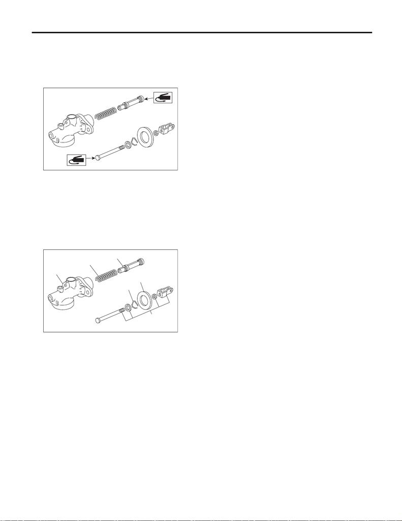

CL-26

Master Cylinder

CLUTCH SYSTEM

D: ASSEMBLY

1) Apply a coat of grease to the contact surfaces of

the push rod and piston before installation.

Grease:

SILICONE GREASE G-40M or equivalent

2) Assemble in the reverse order of disassembly.

Tightening torque:

10 N·m (1.0 kgf-m, 7.4 ft-lb)

E: INSPECTION

If any damage, deformation, wear, swelling, rust or

other faults are found on the cylinder, piston, push

rod, reservoir tank, return spring, breather screw,

seat or hose, replace the faulty part.

(A) Master cylinder body

(B) Return spring

(C) Piston

(D) Piston stop ring

(E) Push rod ASSY

(F) Seat

CL-01008

CL-01009

(B)

(C)

(D)

(E)

(A)

(F)